# Brazilian_sales_data_analysis_with_interpretations (1)

# 8. The % of total revenue contributed by each product category is:

```python
query="""SELECT upper(products.product_category) category,
round((sum(payments.payment_value)/(select sum(payment_value) from payments))*100,2) sales_percentage
FROM products join order_items on products.product_id=order_items.product_id
join payments on payments.order_id=order_items.order_id
group by category order by sales_percentage desc"""
cur.execute(query)
data=cur.fetchall()
data
df=pd.DataFrame(data, columns=["category", "percentage_sales"])

df.head(10)
```

|  | category | percentage_sales |
| --- | --- | --- |
| 0 | BED TABLE BATH | 21.40 |
| 1 | HEALTH BEAUTY | 20.71 |
| 2 | COMPUTER ACCESSORIES | 19.81 |
| 3 | FURNITURE DECORATION | 17.87 |
| 4 | WATCHES PRESENT | 17.86 |
| 5 | SPORT LEISURE | 17.39 |
| 6 | HOUSEWARES | 13.68 |
| 7 | AUTOMOTIVE | 10.65 |
| 8 | GARDEN TOOLS | 10.47 |
| 9 | COOL STUFF | 9.74 |

### 💰 Interpretation of Revenue Contribution by Product Category

The category contributing the highest percentage of total revenue is "BED TABLE BATH", accounting for 21.40% of total sales, followed closely by "HEALTH BEAUTY" and "COMPUTER ACCESSORIES", contributing 20.71% and 19.81% respectively. These categories clearly dominate revenue generation, likely due to their broad utility, frequent demand, or high average order value.

Other significant contributors include "FURNITURE DECORATION", "WATCHES PRESENT", and "SPORT LEISURE", each contributing between 17% and 18%. These categories may represent popular lifestyle or gifting segments.

Overall, revenue is concentrated among a few top-performing product categories, which reflects consumer preferences and possibly the effectiveness of marketing, pricing, and inventory strategies in those areas.

# 9. The correlation between product price and the number of times a product has been purchased is:

```python
query="""select products.product_category, count(order_items.product_id),
round(avg(order_items.price),2)
from products join order_items on
products.product_id=order_items.product_id
group by products.product_category"""
cur.execute(query)
data=cur.fetchall()
data
df=pd.DataFrame(data, columns=["category", "order_count", "price"])

df.head(10)
```

|  | category | order_count | price |
| --- | --- | --- | --- |
| 0 | HEALTH BEAUTY | 19340 | 130.16 |
| 1 | sport leisure | 17282 | 114.34 |
| 2 | Cool Stuff | 7592 | 167.36 |
| 3 | computer accessories | 15654 | 116.51 |
| 4 | Watches present | 11982 | 201.14 |
| 5 | housewares | 13928 | 90.79 |
| 6 | electronics | 5534 | 57.91 |
| 7 | None | 3206 | 112.00 |
| 8 | toys | 8234 | 117.55 |
| 9 | bed table bath | 22230 | 93.30 |

```python
import numpy as np
arr1=df["order_count"]
arr2=df["price"]
np.corrcoef([arr1, arr2])
```

```
array([[ 1.        , -0.10631514],
       [-0.10631514,  1.        ]])
```

### 📈 Interpretation of Correlation Between Product Price and Purchase Count

From the data, there doesn’t appear to be a strong positive or negative correlation between the average price of a product category and the number of times it has been purchased. For instance, "BED TABLE BATH" has the highest order count (22,230) despite a relatively moderate average price of ₹93.30, while "COOL STUFF" has fewer orders (7,592) but a higher average price of ₹167.36.

Categories like "HEALTH BEAUTY" and "SPORT LEISURE" also show high purchase counts with mid-range prices, while "WATCHES PRESENT" has a higher price (₹201.14) and fewer orders in comparison. This suggests that purchase frequency is not necessarily driven by price alone, but likely influenced by product utility, demand, customer preferences, and category relevance.

Overall, the relationship between price and purchase volume appears weak or inconsistent across categories, indicating that other factors are playing a more significant role in influencing buying behavior.

# scatter plot of order count vs. average product price:

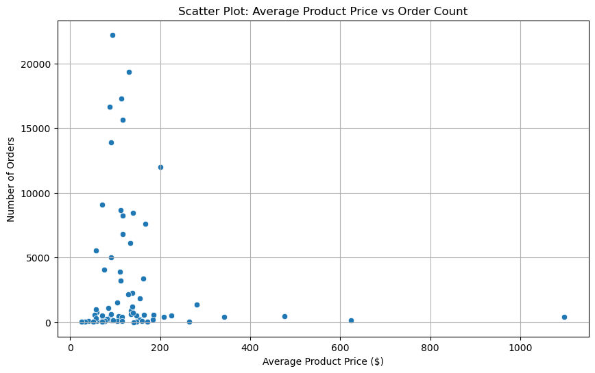

```python
import matplotlib.pyplot as plt
import seaborn as sns

plt.figure(figsize=(10,6))
sns.scatterplot(x='price', y='order_count', data=df)
plt.title('Scatter Plot: Average Product Price vs Order Count')
plt.xlabel('Average Product Price ($)')
plt.ylabel('Number of Orders')
plt.grid(True)
plt.show()
```

### 📉 Interpretation of Scatter Plot: Average Product Price vs. Order Count

The scatter plot shows the relationship between the average price of products in each category and the number of times they were ordered. The data points appear widely scattered without forming a clear upward or downward trend, indicating the absence of a strong linear relationship.

Some categories with relatively low prices have very high order counts, such as "BED TABLE BATH", while others with higher average prices, like "WATCHES PRESENT" or "COOL STUFF", have comparatively fewer orders. This suggests that products with lower prices tend to be ordered more frequently, but the pattern is not strong or consistent across all categories.

Overall, the plot supports the earlier statistical result showing a weak negative correlation. Price does not appear to be a dominant factor in determining how frequently a product category is purchased, and other factors like product type, necessity, and popularity are likely influencing customer behavior.

# 10. The total revenue generated by each seller, and ranked by revenue is:

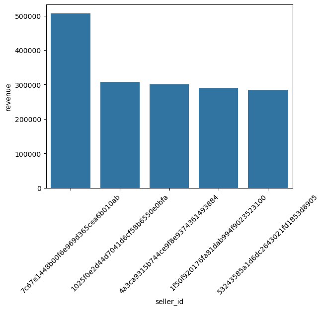

```python
query="""select*, dense_rank() over(order by revenue desc) as rn from
(select order_items.seller_id, sum(payments.payment_value) revenue
from order_items join payments on order_items.order_id=payments.order_id
group by order_items.seller_id) as a"""
cur.execute(query)
data=cur.fetchall()
data
df=pd.DataFrame(data, columns=["seller_id", "revenue", "ranks"])
df=df.head()
sns.barplot(x="seller_id", y="revenue", data=df)
plt.xticks(rotation=45)
plt.show()
```

```python
df=df.head()
df
```

|  | seller_id | revenue | ranks |
| --- | --- | --- | --- |
| 0 | 7c67e1448b00f6e969d365cea6b010ab | 507166.907302 | 1 |
| 1 | 1025f0e2d44d7041d6cf58b6550e0bfa | 308222.039840 | 2 |
| 2 | 4a3ca9315b744ce9f8e9374361493884 | 301245.269765 | 3 |
| 3 | 1f50f920176fa81dab994f9023523100 | 290253.420128 | 4 |
| 4 | 53243585a1d6dc2643021fd1853d8905 | 284903.080498 | 5 |

### 💼 Interpretation of Top 5 Sellers by Revenue:

The table and bar plot show the top 5 sellers ranked by total revenue in dollars. The leading seller (`7c67e1448b00f6e969d365cea6b010ab`) generated about \$507,167, which is significantly higher than the second-ranked seller with approximately \$308,222 in revenue.

There is a clear gap between the top seller and the others, indicating that the highest-ranked seller dominates in terms of sales. Sellers ranked 2 to 5 have closer revenue values, ranging between roughly \$285,000 and \$308,000, suggesting strong competition within this group.

These sellers likely excel due to high product demand, competitive pricing, or efficient operations, making them key contributors to the platform’s overall revenue.

# 11. The Moving average of order values for each customers over their order history is:

```python
query="""select customer_id, order_purchase_timestamp, payment,
avg(payment) over (partition by customer_id order by order_purchase_timestamp
rows between 2 preceding and current row) as mov_avg
from
(select orders.customer_id, orders.order_purchase_timestamp,
payments.payment_value as payment
from payments join orders on payments.order_id=orders.order_id) as a;
"""
cur.execute(query)
data=cur.fetchall()
df=pd.DataFrame(data, columns=["customer_id", "timestamp", "price", "moving_average"])
df
```

|  | customer_id | timestamp | price | moving_average |
| --- | --- | --- | --- | --- |
| 0 | 00012a2ce6f8dcda20d059ce98491703 | 2017-11-14 16:08:26 | 114.74 | 114.739998 |
| 1 | 00012a2ce6f8dcda20d059ce98491703 | 2017-11-14 16:08:26 | 114.74 | 114.739998 |
| 2 | 000161a058600d5901f007fab4c27140 | 2017-07-16 09:40:32 | 67.41 | 67.410004 |
| 3 | 000161a058600d5901f007fab4c27140 | 2017-07-16 09:40:32 | 67.41 | 67.410004 |
| 4 | 0001fd6190edaaf884bcaf3d49edf079 | 2017-02-28 11:06:43 | 195.42 | 195.419998 |
| ... | ... | ... | ... | ... |
| 207767 | ffff42319e9b2d713724ae527742af25 | 2018-06-13 16:57:05 | 214.13 | 214.130005 |
| 207768 | ffffa3172527f765de70084a7e53aae8 | 2017-09-02 11:53:32 | 45.50 | 45.500000 |
| 207769 | ffffa3172527f765de70084a7e53aae8 | 2017-09-02 11:53:32 | 45.50 | 45.500000 |
| 207770 | ffffe8b65bbe3087b653a978c870db99 | 2017-09-29 14:07:03 | 18.37 | 18.370001 |
| 207771 | ffffe8b65bbe3087b653a978c870db99 | 2017-09-29 14:07:03 | 18.37 | 18.370001 |

207772 rows × 4 columns

### 📊 Interpretation of Moving Average of Order Values per Customer

The moving average column represents the average payment amount for each customer calculated over their current order and the two previous orders, ordered by purchase date. This smooths out short-term fluctuations in individual order values, helping to identify trends in a customer's purchasing behavior over time.

For example, if a customer's order values are generally increasing, their moving average will gradually rise, showing increased spending. Conversely, if order values drop or vary greatly, the moving average will smooth those changes to provide a clearer view of the overall trend.

This metric is useful for understanding customer loyalty and purchasing patterns, as it highlights whether customers tend to increase, decrease, or maintain their spending across multiple purchases.

# 12. The cumulative sales per month for each year is:

```python
query=""" select years, months, payment, sum(payment)
over (order by years, months) cumulative_sales from
(select year(orders.order_purchase_timestamp) as years,
month(orders.order_purchase_timestamp) as months,
round(sum(payments.payment_value),2) as payment
from orders join payments on orders.order_id=payments.order_id
group by years, months order by years, months) as a;

"""
cur.execute(query)
data=cur.fetchall()
df=pd.DataFrame(data, columns=["years", "months", "payment", "cumulative_sales"])
df
```

|  | years | months | payment | cumulative_sales |
| --- | --- | --- | --- | --- |
| 0 | 2016 | 9 | 504.48 | 504.48 |
| 1 | 2016 | 10 | 118180.96 | 118685.44 |
| 2 | 2016 | 12 | 39.24 | 118724.68 |
| 3 | 2017 | 1 | 276976.08 | 395700.76 |
| 4 | 2017 | 2 | 583816.02 | 979516.78 |
| 5 | 2017 | 3 | 899727.20 | 1879243.98 |
| 6 | 2017 | 4 | 835576.06 | 2714820.04 |
| 7 | 2017 | 5 | 1185837.64 | 3900657.68 |
| 8 | 2017 | 6 | 1022552.76 | 4923210.44 |
| 9 | 2017 | 7 | 1184765.84 | 6107976.28 |
| 10 | 2017 | 8 | 1348792.64 | 7456768.92 |
| 11 | 2017 | 9 | 1455524.90 | 8912293.82 |
| 12 | 2017 | 10 | 1559355.76 | 10471649.58 |
| 13 | 2017 | 11 | 2389765.60 | 12861415.18 |
| 14 | 2017 | 12 | 1756802.96 | 14618218.14 |
| 15 | 2018 | 1 | 2230008.36 | 16848226.50 |
| 16 | 2018 | 2 | 1984926.68 | 18833153.18 |
| 17 | 2018 | 3 | 2319304.24 | 21152457.42 |
| 18 | 2018 | 4 | 2321570.96 | 23474028.38 |
| 19 | 2018 | 5 | 2307964.30 | 25781992.68 |
| 20 | 2018 | 6 | 2047761.00 | 27829753.68 |
| 21 | 2018 | 7 | 2133081.50 | 29962835.18 |
| 22 | 2018 | 8 | 2044850.64 | 32007685.82 |
| 23 | 2018 | 9 | 8879.08 | 32016564.90 |
| 24 | 2018 | 10 | 1179.34 | 32017744.24 |

### 📈 Interpretation of Cumulative Monthly Sales Over Years

The table shows the monthly sales and their cumulative totals from September 2016 through October 2018.

Starting with relatively low sales in late 2016, there is a rapid increase in monthly sales beginning in early 2017. Each month’s sales are added to the previous months to give a running total of revenue generated over time.

The cumulative sales steadily grow, reflecting consistent and substantial revenue generation month after month. The sharp rise in cumulative sales through 2017 and 2018 suggests strong business growth and increasing customer purchases.

The small sales values in September and October 2018 compared to previous months might indicate incomplete data for those months or a drop in sales activity toward the end of the period.

Overall, this cumulative sales trend is a clear indicator of how total revenue accumulates over time, useful for tracking business performance and forecasting future growth.

# The year-over-year growth rate of total sales is:

```python
query="""with a as (select year(orders.order_purchase_timestamp) as years,
round(sum(payments.payment_value),2) as payment
from orders join payments on orders.order_id=payments.order_id
group by years order by years)
select years, ((payment-lag(payment, 1) over (order by years))/
lag(payment, 1) over (order by years))*100 from a

"""
cur.execute(query)
data=cur.fetchall()
df=pd.DataFrame(data, columns=["years", "y_o_y_growth"])
df
```

|  | years | y_o_y_growth |
| --- | --- | --- |
| 0 | 2016 | NaN |
| 1 | 2017 | 12112.703761 |
| 2 | 2018 | 20.000924 |

### 📊 Interpretation of Year-over-Year Growth Rate of Total Sales

The year-over-year (YoY) growth rate measures how much the total sales have increased compared to the previous year.

- In 2016, there is no previous year to compare to, so the growth rate is not available.
- In 2017, there is a massive growth of approximately 12,112.7%, indicating an explosive increase in sales compared to 2016. This unusually high figure suggests that sales in 2016 were very low or the data for 2016 only covers part of the year.
- In 2018, sales continued to grow but at a much more moderate rate of 20%, indicating steady and healthy business expansion compared to 2017.

This YoY growth rate highlights the rapid scale-up phase of the business followed by a period of sustained growth.

# 14. The retention rate of customer, defined as the % of customers who make another purchase within 6 months of their first purchase is:

```python
query="""WITH first_orders AS (
    SELECT
        customers.customer_id,
        MIN(orders.order_purchase_timestamp) AS first_order
    FROM customers
    JOIN orders ON customers.customer_id = orders.customer_id
    GROUP BY customers.customer_id
),
subsequent_orders AS (
    SELECT
        a.customer_id,
        COUNT(DISTINCT orders.order_id) AS purchase_count
    FROM first_orders a
    LEFT JOIN orders ON orders.customer_id = a.customer_id
        AND orders.order_purchase_timestamp > a.first_order
        AND orders.order_purchase_timestamp <= DATE_ADD(a.first_order, INTERVAL 6 MONTH)
    GROUP BY a.customer_id
)
SELECT
    COUNT(CASE WHEN purchase_count >= 1 THEN 1 END) * 100.0 / COUNT(*) AS retention_rate_percentage
FROM subsequent_orders;"""

cur.execute(query)
data = cur.fetchall()
df = pd.DataFrame(data, columns=["repeated_purchase_withint_6_month(%)"])
df
```

|  | repeated_purchase_withint_6_month(%) |
| --- | --- |
| 0 | 0.00000 |

### Customer Retention Interpretation

The retention rate measures the percentage of customers who make another purchase within 6 months of their first purchase.

If the retention rate is zero or extremely low, it indicates that customers generally do not return to make repeat purchases in that timeframe. This might signal issues such as lack of customer engagement, low satisfaction, or that the business model is focused on one-time purchases.

A zero retention rate highlights the need to investigate customer experience, loyalty programs, or marketing strategies to encourage repeat purchases.

# 14. The top 3 customers who spent the most money in each year is:

```python
query="""select years, customer_id, payment, d_rank
from
(select year(orders.order_purchase_timestamp) years, orders.customer_id,
sum(payments.payment_value) payment,
dense_rank() over(partition by year(orders.order_purchase_timestamp)
order by sum(payments.payment_value) desc ) d_rank
from orders join payments
on payments.order_id=orders.order_id
group by year(orders.order_purchase_timestamp),
orders.customer_id) as a
where d_rank <=3;
"""
cur.execute(query)
data = cur.fetchall()
df = pd.DataFrame(data, columns=["years","id","payment","rank"])
df
```

|  | years | id | payment | rank |
| --- | --- | --- | --- | --- |
| 0 | 2016 | a9dc96b027d1252bbac0a9b72d837fc6 | 2847.100098 | 1 |
| 1 | 2016 | 1d34ed25963d5aae4cf3d7f3a4cda173 | 2801.479980 | 2 |
| 2 | 2016 | 4a06381959b6670756de02e07b83815f | 2455.560059 | 3 |
| 3 | 2017 | 1617b1357756262bfa56ab541c47bc16 | 27328.160156 | 1 |
| 4 | 2017 | c6e2731c5b391845f6800c97401a43a9 | 13858.620117 | 2 |
| 5 | 2017 | 3fd6777bbce08a352fddd04e4a7cc8f6 | 13453.320312 | 3 |
| 6 | 2018 | ec5b2ba62e574342386871631fafd3fc | 14549.759766 | 1 |
| 7 | 2018 | f48d464a0baaea338cb25f816991ab1f | 13844.419922 | 2 |
| 8 | 2018 | e0a2412720e9ea4f26c1ac985f6a7358 | 9618.879883 | 3 |

# Visualisation of Top 3 customers who spents more money in each year:

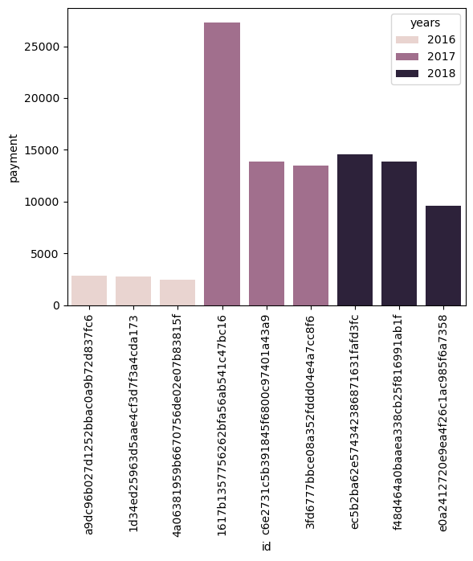

```python
sns.barplot(x="id", y="payment", data=df, hue="years")
plt.xticks(rotation=90)
plt.show()
```

### Intrepretation of the Top 3 customers based on their spending in each year

The data presents the top three customers who spent the most money in each year from 2016 to 2018.

In 2016, the highest spending customer made purchases totaling approximately \$2,847, followed closely by two others spending \$2,801 and \$2,455 respectively. These spending figures are relatively moderate.

In 2017, there is a significant increase in customer spending. The top customer spent over $27,328, while the second and third highest spent \$13,858 and \$13,453 respectively. This reflects a major growth in high-value purchases.

## 📊 Final Conclusion and Recommendations

### ✅ Recommendations

1. **Enhance Loyalty Programs**: Introduce targeted loyalty incentives or reward systems to improve customer retention and encourage repeat purchases, especially within the first 6 months.
2. **Installment Optimization**: Given the popularity of installment payments, consider offering optimized financing plans or partnering with credit providers to make installment purchases even more attractive.
3. **Focus on High-Revenue States**: Prioritize marketing campaigns and logistics improvements in high-performing states like SP, MG, and RJ to maximize reach and ROI.
4. **Category Expansion**: Since a few product categories dominate revenue, consider diversifying within these segments (e.g., more premium Health & Beauty or Bed & Bath lines).
5. **Seller Diversification**: Encourage onboarding of more sellers and reduce over-dependence on top-performing sellers to minimize operational risk.
6. **Seasonal Campaigns**: Capitalize on order surges during May–August through discounts, bundle offers, or free shipping to drive even greater volume.
7. **Monitor Price Sensitivity**: Since there’s a slight negative correlation between price and order volume, continue to balance pricing strategies—consider offering value bundles for higher-priced items.
8. **Customer Segmentation**: Identify and nurture high-value customers using CRM tools and exclusive offers to retain them.

By implementing these recommendations, the platform can improve customer experience, optimize revenue growth, and ensure long-term sustainability.